# Session 5

## Session outline

1. Base R plots
2. `ggplot2` package
3. Other useful packages

## Base R plots

1. Generic plot types in R
- Scatter plots
- Histogram / density plots
- Bar plots
- Box plots
- Line plots
- Pie charts
2. Combining multiple plots
- How to add a new layer on top of an existing plot
- How to create a matrix of plots
3. Saving graphs
- Format output

## Base R plots

### Scatter Plot – [`plot()`](https://www.rdocumentation.org/packages/graphics/versions/3.6.2/topics/plot) function

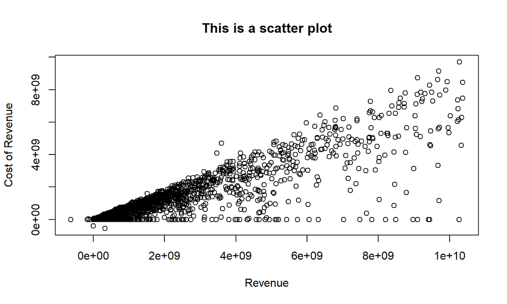

```r
# Data set
df_i <-read.csv("data/finance_example.csv")
# Plot Cost of Revenue on Revenue
# Note: there are outliers
df_i %>%
  filter(
    Revenue < quantile(Revenue, 0.9,
      na.rm = T)) -> df

plot(df$Revenue, df$Cost.of.Revenue,
     main="This is a scatter plot",
     ylab="Cost of Revenue",
     xlab="Revenue")
     # xlim=c(lower_bound, upper_bound)
     # ylim=c(lower_bound, upper_bound)
```

## Base R plots

### Histogram – [`hist()`](https://www.rdocumentation.org/packages/graphics/versions/3.6.2/topics/hist) function

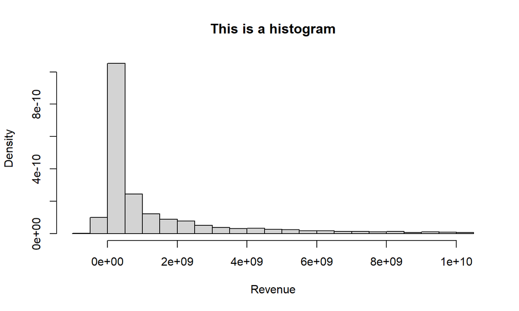

```r
# Plot histogram of Revenue
hist(df$Revenue,
     breaks = 30,
     freq = F,
     # if freq = F -> prob. density
     # if freq = T -> count
     main="This is a histogram",
     xlab="Revenue")
```

## Base R plots

### Composing Multiple Plots 1

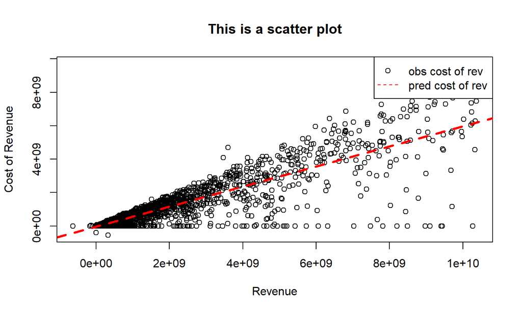

```r
# Plot regression Line over a scatter plot
lmodel = lm(df$Cost.of.Revenue ~ df$Revenue)
# Bottom layer
plot(df$Revenue, df$Cost.of.Revenue,
     main="This is a scatter plot",
     ylab="Cost of Revenue",
     xlab="Revenue")
# Add a line Layer
abline(lmodel, col="red", lty=2, lwd=3)
# Add a legend layer
legend("topright",
       legend=c("obs cost of rev", "pred cost of rev"),
       col=c("black", "red"),
       pch=c(1,26),  # point character
       lty=c(0, 2)   # line types
       )
```

## Base R plots

### Composing Multiple Plots 2.1

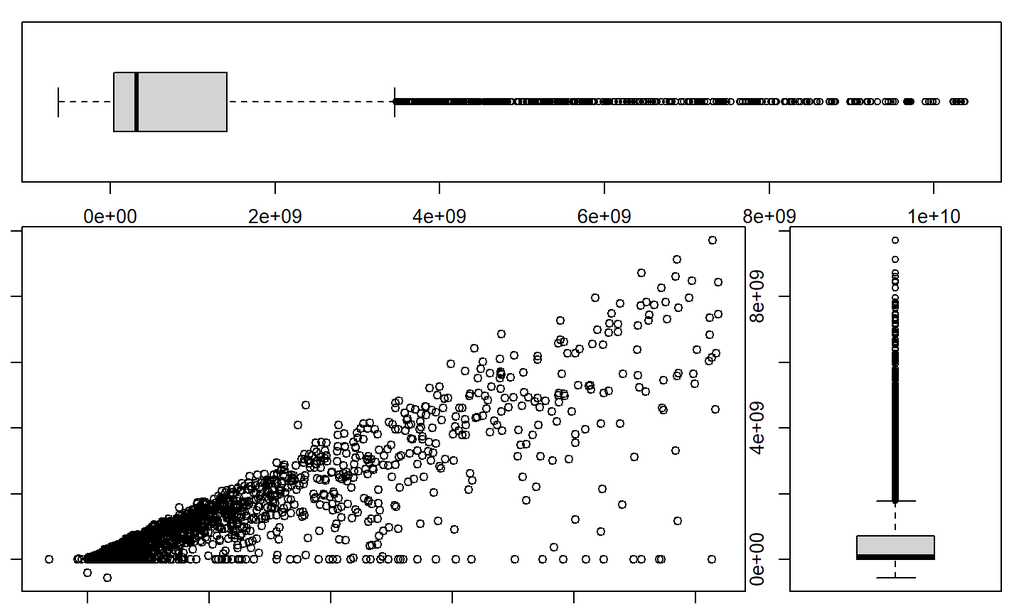

```r
# Change the figure margins
par(mar=c(1,1,1,1))

# Set layout
layout(matrix(c(1,1,2,3), nrow=2, byrow=T),
       widths=c(3,1), heights = c(1,2))
# plot1: Horizontal boxplot of revenue
boxplot(df$Revenue, horizontal=T)
# plot2: Plot of rev. vs. cost of rev.
plot(df$Revenue, df$Cost.of.Revenue)
# plot3: vertical boxplot of cost of rev.
boxplot(df$Cost.of.Revenue)
```

## Base R plots

### Composing Multiple Plots 2.2

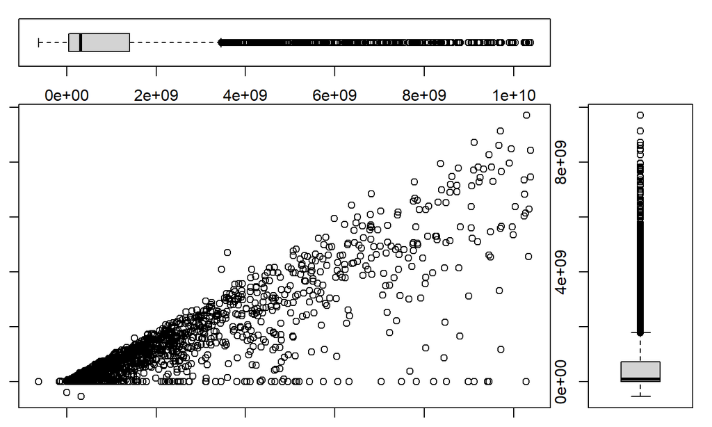

```r
# fig=c(x1,x2, y1, y2) x & y range from 0 - 1
plot.new()
par(mar=c(1,1,1,1))

# plot1: Horizontal boxplot of revenue
par(fig=c(0,0.8,0.8,1), new=TRUE)
boxplot(df$Revenue, horizontal=T)

# plot2: Plot of rev. vs. cost of rev.
par(fig=c(0,0.8,0,0.8), new=TRUE)
plot(df$Revenue, df$Cost.of.Revenue)

# plot3: vertical boxplot of cost of rev.
par(fig=c(0.8,1,0,0.8), new=TRUE)
boxplot(df$Cost.of.Revenue)
```

## Base R plots

### Composing Multiple Plots 2.3

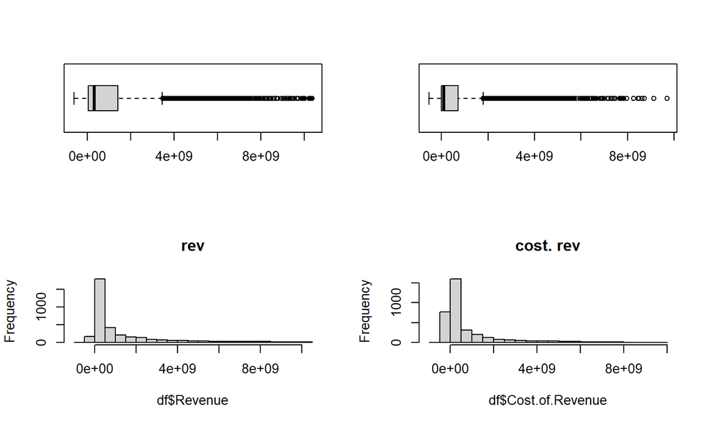

```r
par(mfrow=c(2,2))

# plot1: boxplot of revenue
boxplot(df$Revenue, horizontal = T)
# plot2: boxplot of cost of rev.
boxplot(df$Cost.of.Revenue, horizontal = T)
# plot3: histogram of revenue
hist(df$Revenue, breaks = 30, main="rev")
# plot4: histogram of cost of rev.
hist(df$Cost.of.Revenue, breaks=30,
     main="cost. rev")
```

## ggplot2

### The Grammar of Graphics

Decomposing graphics

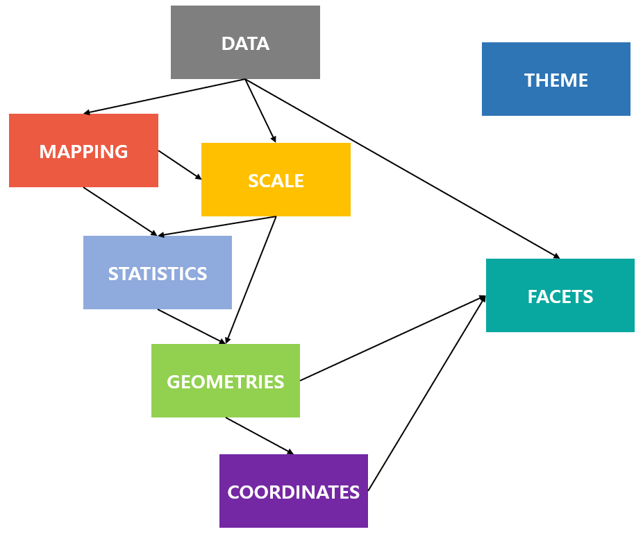

## ggplot2

### Data

Defines what we can be visualized

`ggplot` requires the data to be in a `data.frame` format

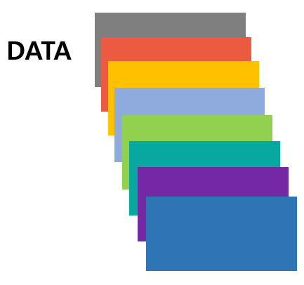

## ggplot2

### Mapping

Aesthetic mapping `aes()`:  
Variables (Data) ↔ Graphical Properties (Geometries)

- Mapping requirements by geoms

Facet mapping:  
Variables (Data) ↔ Panels (Facet)

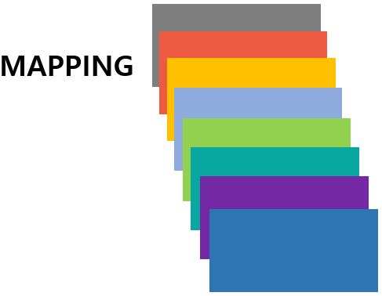

## ggplot2

### Geometries

Interprets aesthetics as graphical representation

Determines the plot type

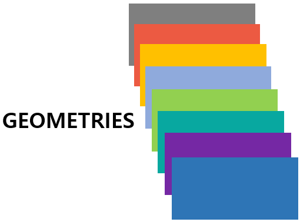

```r
# Basic Syntax
ggplot() +       # Note: `+` is used to add ggplot elements!
  <geom_function>(data=<DATA>, mapping=aes(<mappings>))

# Global data
ggplot(data=<DATA>) +
  <geom_function>(mapping=aes(<mappings>))

# Global data and Mapping
ggplot(data=<DATA>, mapping=aes(<mappings>)) +
  <geom_function>()
```

## ggplot2

### Example

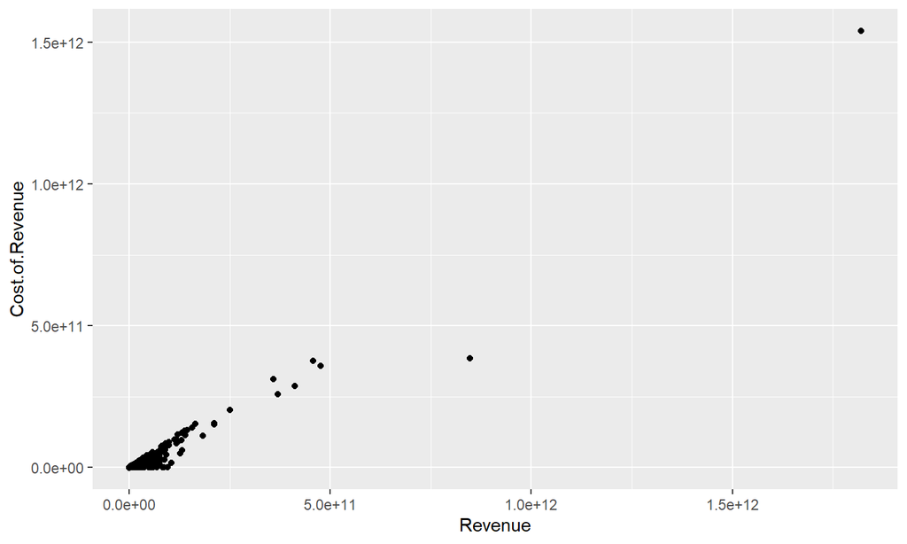

```r
df<-read.csv("data/finance_example.csv")
# str(df)
library(ggplot2)
ggplot(data=df,
  # data: which dataset to plot
  mapping=aes(
    x=Revenue,
    y=Cost.of.Revenue)) +
  # aes: variables for x and y
  geom_point()
  # geom_point: scatter plot
```

## ggplot2

### Example

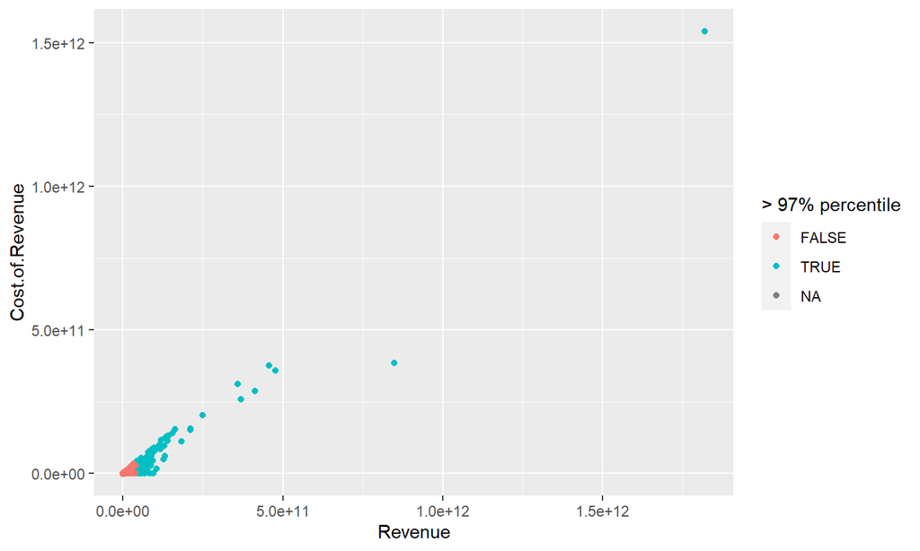

```r
df %>%
  ggplot(mapping=aes(
    x=Revenue,
    y=Cost.of.Revenue,
    color=Revenue > quantile(df$Revenue,0.97, na.rm=T))) +
  # Other commonly used aes args
  # fill, size, shape, alpha
  geom_point()+
  guides(color=guide_legend(title="> 97% percentile"))
```

## ggplot2

### Mapping vs. Setting

```r
# Mapping
ggplot(data=df,
  mapping=aes(
    x=Revenue,
    y=Cost.of.Revenue,
    color= Sector)) +
  # color within aes
  geom_point()
```

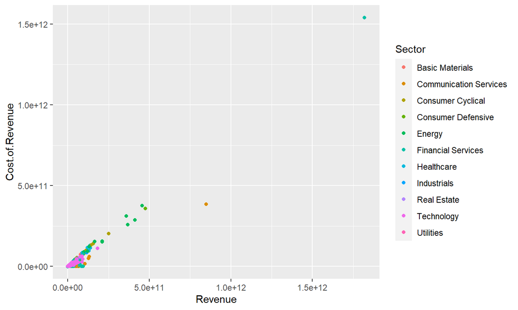

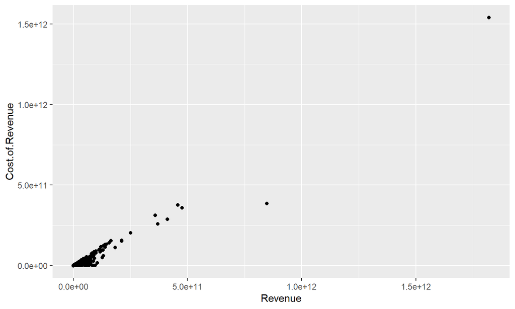

```r
# Setting
ggplot(data=df,
  mapping=aes(
    x=Revenue,
    y=Cost.of.Revenue),
  color= Sector) +
  # color outside aes
  geom_point()
```

## ggplot2

### Mapping and Geometries

Produces the same output

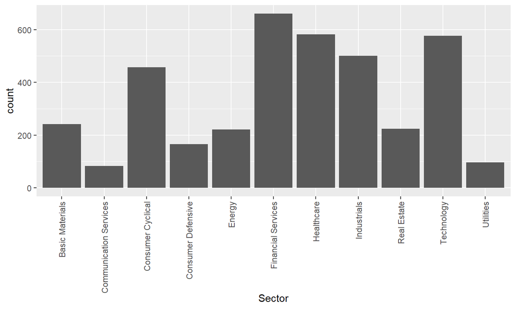

```r
# Plot1
ggplot(data = df) +
  stat_count(mapping = aes(x = Sector))
# Plot2
ggplot(data = df) +
  geom_bar(mapping = aes(x = Sector))
# Plot3
df %>%
  group_by(Sector) %>%
  summarize(freq=n()) %>%
  ggplot() +
  geom_bar(mapping = aes(x = Sector, y = freq),
           stat = "identity")
```

## ggplot2

### Statistics

1. Linked to Geometries (usually has a default stat)
2. Transform input variables
3. Can be done prior to plotting

```r
df %>%
  count(Sector, name="freq") %>%
  ggplot() +
  geom_col(aes(x=Sector, y=freq))
```

```r
df %>%
  ggplot() +
  geom_bar(aes(
    x=Sector,
    y=after_stat( count / sum(count)*100))
  )
```

## ggplot2

### Scales

1. Everything inside aes have scales
2. Scales have the following naming format

```r
scale_<aes>_<type>()
# Example
scale_x_continuous()
```

## ggplot2

### Scales - Examples

```r
df<-read.csv("data/finance_example.csv")
# Recall that df has many outliers
```

```r
ggplot(data=df,
  aes(x=Revenue,
    y=Cost.of.Revenue)) +
  geom_point()
```

```r
df<-read.csv("data/finance_example.csv")
# Recall that df has many outliers
ggplot(data=df,
  mapping=aes(x=Revenue,y=Cost.of.Revenue)) +
  geom_point()+
  scale_x_continuous(
    limits=c(0, 2.5*10^11),
    breaks=seq(0, 2.5*10^11, by=10^11)
  )+
  ylim(0, 2*10^11)
```

## ggplot2

### Scales - Examples2

```r
df<-read.csv("data/finance_example.csv")
# Recall that df has many outliers
```

```r
df<-read.csv("data/finance_example.csv")
# Recall that df has many outliers
ggplot(data=df,
  mapping=aes(x=Revenue,y=Cost.of.Revenue,
              color=Sector)) +
  geom_point()+
  scale_x_continuous(
    trans="log10"
  )+
  ylim(0, 2*10^11)
```

## ggplot2

### Facets

1. Split data by categories into multiple panels
2. Each panel has the same underlying mechanism
3. Can also be used to avoid overplotting

```r
df %>%
  ggplot()+
  geom_point(aes(x=Revenue, y=Cost.of.Revenue))+
  # facet_wrap(~ Sector)                     # Facet is often the best way to avoid overplotting
  # facet_wrap(~ Sector, scales='free')      # free_y or free_x
  # facet_grid(partition ~ Sector)           # facet_grid graphic pivots
  # facet_wrap(~ drv+year)                   # Subsetting data
```

```r
ggplot(df)+
  geom_bar(aes(y=Sector))+
  # facet_grid(Sector ~ .)
  facet_grid(Sector ~ ., scale="free_y" , space="free_y")
```

## ggplot2

### Coordinates

1. Positional aesthetics are interpreted by a coordinate system  
   – How x and y should be interpreted
2. Defines physical mapping

## ggplot2

### Coordinates - Examples

```r
# Polar coordinates
df %>%
  ggplot()+
  geom_bar(aes(x=Sector))+
  coord_polar()
# Coord flip
df %>%
  ggplot()+
  geom_bar(aes(x=Sector))+
  coord_flip()
# Zoom-in
df %>%
  ggplot()+
  geom_bar(aes(x=Sector))+
  # scale_y_continuous(limits=c(0, 300))
  coord_cartesian(ylim=c(0, 300))
```

## ggplot2

### Themes

1. Visuals of the plot – Stylistic changes
2. Not linked to data
3. Elements for the themese could be modified separately

## ggplot2

### Themes – Example

```r
df %>%
  ggplot()+
  geom_bar(aes(x=Sector))+
  facet_wrap(~ partition)+
  theme_minimal()          # There are built-in themes
```

## ggplot2

### Themes – Example

```r
df %>%
  ggplot()+
  geom_bar(aes(x=Sector))+
  facet_wrap(~ partition)+
  theme_minimal()+
  labs(
    title="this is a title",
    caption="this is a caption",
    x="this is x-axis label",
    y="this is y-axis label"
       )+
  theme(
    axis.text = element_text(colour = "red", size = rel(1.5), family = "serif"),
    panel.grid.major = element_line("steelblue"),
    # panel.grid.major.y = element_blank(),
    panel.grid.major.x = element_blank()
  )
```